# R Notebook

```r
library(tidyverse)
library(janitor)
library(infer)
```

## Task 1

Load the data, clean_names(), and familiarise yourself with it.

| order | pid | ms_sub_class | ms_zoning | lot_frontage | lot_area | street | alley | lot_shape | land_contour | utilities | lot_config | land_slope | neighborhood | condition_1 | condition_2 | bldg_type | house_style | overall_qual | overall_cond | year_built | year_remod_add | roof_style | roof_matl | exterior_1st | exterior_2nd | mas_vnr_type | mas_vnr_area | exter_qual | exter_cond | … |
| --- | --- | --- | --- | --- | --- | --- | --- | --- | --- | --- | --- | --- | --- | --- | --- | --- | --- | --- | --- | --- | --- | --- | --- | --- | --- | --- | --- | --- | --- | --- |
| 1 | 526301100 | 20 | RL | 141 | 31770 | Pave | NA | IR1 | Lvl | AllPub | Corner | Gtl | NAmes | Norm | Norm | 1Fam | 1Story | 6 | 5 | 1960 | 1960 | Hip | CompShg | BrkFace | Plywood | Stone | 112 | TA | TA | … |
| 2 | 526350040 | 20 | RH | 80 | 11622 | Pave | NA | Reg | Lvl | AllPub | Inside | Gtl | NAmes | Feedr | Norm | 1Fam | 1Story | 5 | 6 | 1961 | 1961 | Gable | CompShg | VinylSd | VinylSd | None | 0 | TA | TA | … |
| 3 | 526351010 | 20 | RL | 81 | 14267 | Pave | NA | IR1 | Lvl | AllPub | Corner | Gtl | NAmes | Norm | Norm | 1Fam | 1Story | 6 | 6 | 1958 | 1958 | Hip | CompShg | Wd Sdng | Wd Sdng | BrkFace | 108 | TA | TA | … |
| 4 | 526353030 | 20 | RL | 93 | 11160 | Pave | NA | Reg | Lvl | AllPub | Corner | Gtl | NAmes | Norm | Norm | 1Fam | 1Story | 7 | 5 | 1968 | 1968 | Hip | CompShg | BrkFace | BrkFace | None | 0 | Gd | TA | … |
| 5 | 527105010 | 60 | RL | 74 | 13830 | Pave | NA | IR1 | Lvl | AllPub | Inside | Gtl | Gilbert | Norm | Norm | 1Fam | 2Story | 5 | 5 | 1997 | 1998 | Gable | CompShg | VinylSd | VinylSd | None | 0 | TA | TA | … |
| 6 | 527105030 | 60 | RL | 78 | 9978 | Pave | NA | IR1 | Lvl | AllPub | Inside | Gtl | Gilbert | Norm | Norm | 1Fam | 2Story | 6 | 6 | 1998 | 1998 | Gable | CompShg | VinylSd | VinylSd | BrkFace | 20 | TA | TA | … |

## Task 2

Investigate the distribution of lot_area. Is the distribution roughly normal? If not, what problems do you find?

[figure not shown]

```r
# five number summary
ames %>%
  select(lot_area) %>%
  skim()
```

```
── Data Summary ────────────────────────
                           Values
Name                       Piped data
Number of rows             2930
Number of columns          1
_______________________
Column type frequency:
  numeric                  1
________________________
Group variables            None
```

|  | skim_variable | n_missing | complete_rate | mean | sd | p0 | p25 | p50 | p75 | p100 | hist |
| --- | --- | --- | --- | --- | --- | --- | --- | --- | --- | --- | --- |
| 1 | lot_area | 0 | 1 | 10147.92 | 7880.018 | 1300 | 7440.25 | 9436.5 | 11555.25 | 215245 | ▇▁▁▁▁ |

The distribution is unimodal, non-normal, highly right-skewed. The range is strongly affected by outliers.

# Task 3

Compute and visualise a bootstrap sampling distribution for the mean(lot_area) of the sold houses.

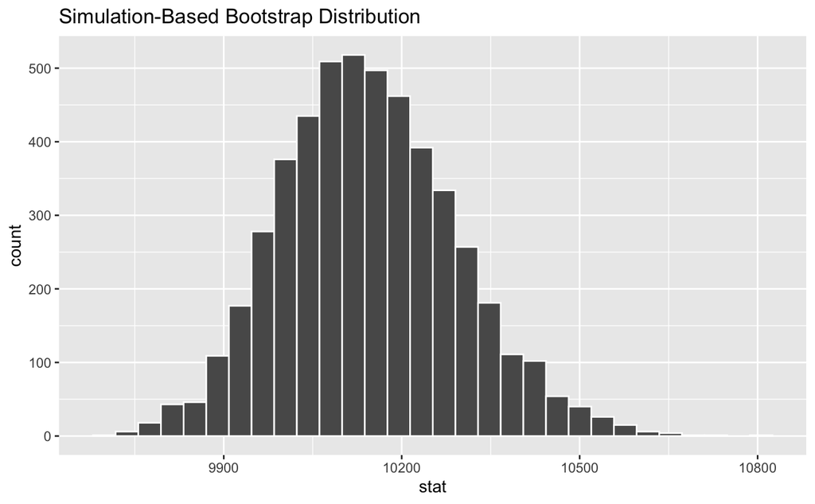

# Task 4

| lower_ci | upper_ci |
| --- | --- |
| 9876.433 | 10456.16 |

## Task 5

You would like to know the mean(lot_area) of the sold houses with higher confidence. Calculate the 99% CI for this variable (you can re-use your bootstrap distribution from above). Is it narrower or broader than the 95% CI? Does that make sense?

```r
ames_ci_99 <- bootstrap_resample_2930 %>%
  summarise(
    mean = mean(mean_lot_area),
    lower_bound = quantile(mean_lot_area, probs = 0.005),
    upper_bound = quantile(mean_lot_area, probs = 0.995)
  )

ames_ci_99
```

| mean | lower_bound | upper_bound |
| --- | --- | --- |
| 10151.14 | 9817.23 | 10544.93 |

The 99% CI for the mean(lot_area) is wider than the 95% CI, as expected (9817.23-10544.93 as opposed to 9876.433-10456.16).

## Task 6

Calculate the point estimate of the mean(lot_area).

```r
mean_infer <- ames_infer_resample %>%
  summarise(mean = mean(stat))

mean_infer
```

| mean |
| --- |
| 10147.55 |

| mean(lot_area) |
| --- |
| 10147.92 |

## Extension

[figure not shown]

[figure not shown]